# Homework 5: Plotting

Solution

## Reading

1. Please read [Chapter 3](https://r4ds.had.co.nz/data-visualisation.html#introduction-1) of R4DS. This is a really nice reference. If you’re interested, look at [section 3.7](https://r4ds.had.co.nz/data-visualisation.html#statistical-transformations) for a deeper understanding of how different statistical transformations can be accommodated within different geometries in ggplot2.

## Exercises

1. Let’s look at the breast cancer data set we’be been using.
   1. Create a bar plot of the frequencies of ER status (Hint: `geom_bar`. How would you modify the dataset so that there is no separate bar for NA’s?

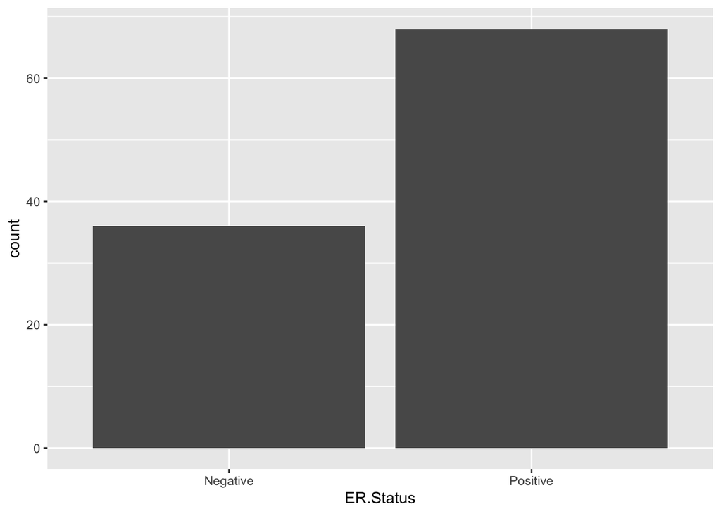

      ```r
      library(tidyverse)
      library(rio)
      brca <- import('data/clinical_data_breast_cancer_hw.csv')
      brca <- brca %>% filter(ER.Status != 'Indeterminate')
      ggplot(brca, aes(x = ER.Status))+geom_bar()
      ```

   2. Color each bar by the frequencies of HER2 status within each group. (Hint: you can add `aes(color='HER2.Status')` or `aes(fill='HER2.Status')` to the `geom_bar` statement. What is the difference in these two choices?)

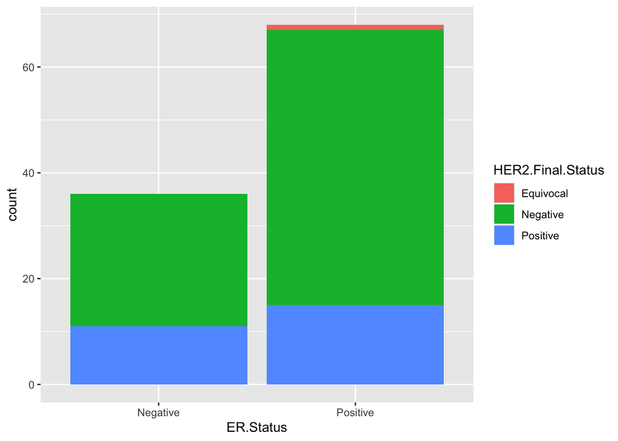

      ```r
      ggplot(brca, aes(x = ER.Status)) + geom_bar(aes(fill=HER2.Final.Status))
      ```

   3. I would like to see a graph showing the relative frequencies of HER2 status within each ER group. Read the documentation `?geom_bar` as well as section 3.8 of R4DS to find this solution.

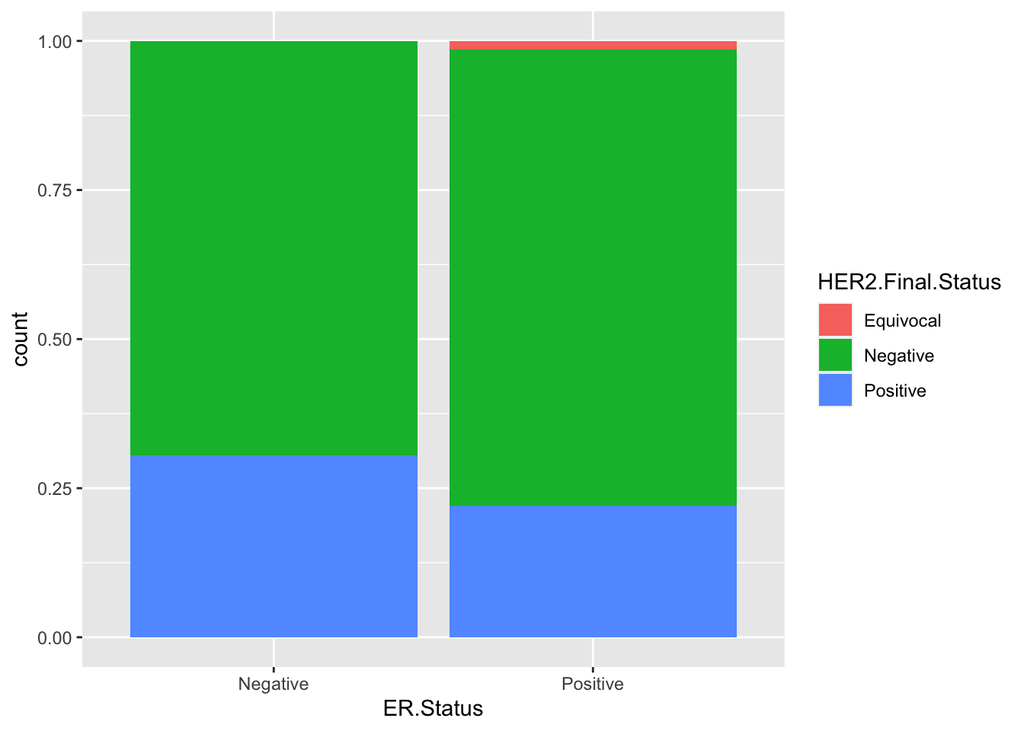

      ```r
      ggplot(brca, aes(x = ER.Status)) + geom_bar(aes(fill=HER2.Final.Status), position='fill')
      ```

2. The `diamonds` dataset is included in the `ggplot2` package.
   1. Add a column to the diamonds dataset that is the volume of each diamond (multiplying the `x`, `y` and `z` variables)

      ```r
      mydiamonds <- diamonds %>%
        mutate(vol = x*y*z)
      ```

   2. Plot a scatter plot of diamond price against diamond volume

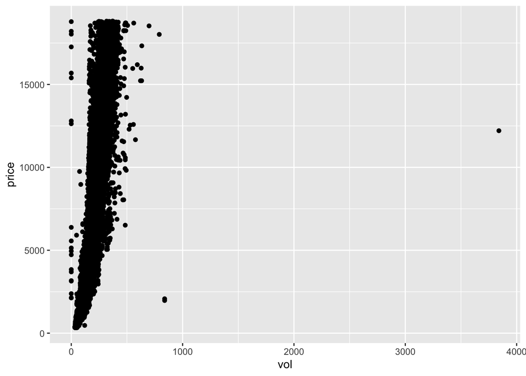

      ```r
      ggplot(mydiamonds, aes(x =vol, y = price)) + geom_point()
      ```

   3. Modify the plot to add colors based on the cut of each diamond

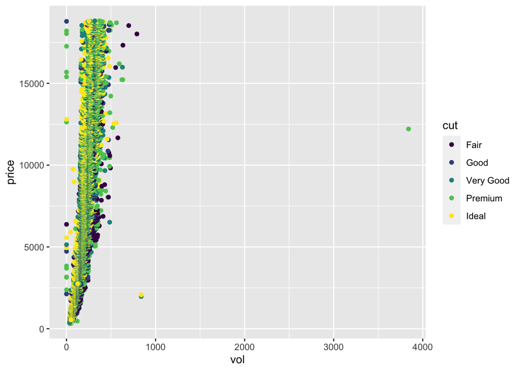

      ```r
      ggplot(mydiamonds, aes(x =vol, y = price, color=cut)) + geom_point()
      ```

   4. Modify the previous plot to construct a facetted plot where each facet is based on a color.

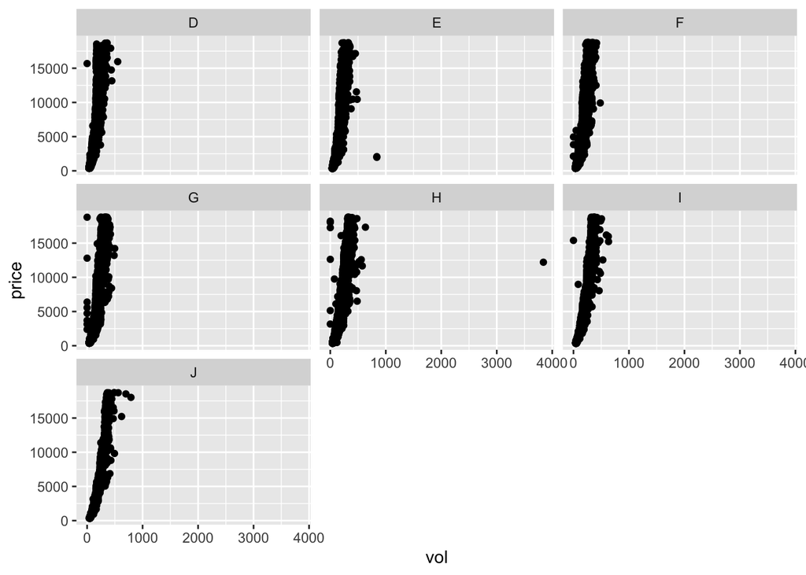

      ```r
      ggplot(mydiamonds, aes(x = vol, y = price))+
        geom_point()+
        facet_wrap(~color)
      ```

### Extra credit

The breast cancer expression dataset contains log-expression levels of 10 probes for the same individuals that are in the clinical dataset.

1. Modify the dataset appropriately and draw a facetted plot where each facet is a histogram of the expression levels of each probe.

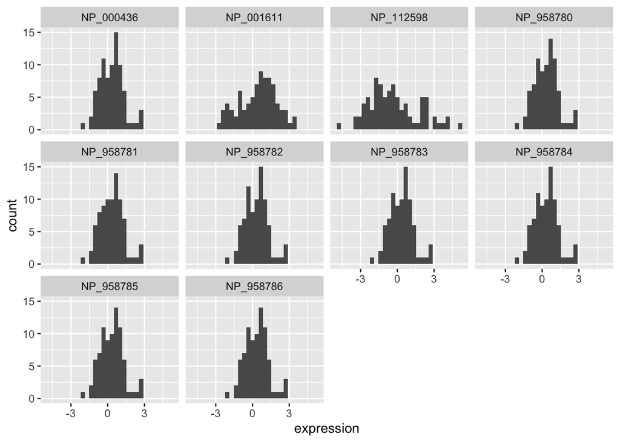

```r
brca_expression <- import('data/BreastCancer_Expression.xlsx')
brca_expression %>% tidyr::gather(probe, expression, starts_with('NP')) %>%
  ggplot(aes(x = expression))+geom_histogram()+
  facet_wrap(~probe)
```